# Reproducible Research: Peer Assessment 1

# Introduction

It is now possible to collect a large amount of data about personal movement using activity monitoring devices such as a [Fitbit](http://www.fitbit.com), [Nike Fuelband](http://www.nike.com/us/en_us/c/nikeplus-fuelband), or [Jawbone Up](https://jawbone.com/up). These type of devices are part of the “quantified self” movement – a group of enthusiasts who take measurements about themselves regularly to improve their health, to find patterns in their behavior, or because they are tech geeks. But these data remain under-utilized both because the raw data are hard to obtain and there is a lack of statistical methods and software for processing and interpreting the data.

This assignment makes use of data from a personal activity monitoring device. This device collects data at 5 minute intervals through out the day. The data consists of two months of data from an anonymous individual collected during the months of October and November, 2012 and include the number of steps taken in 5 minute intervals each day.

## Loading and preprocessing the data

Using data from gihub rdpeng/RepData_PeerAssessment1 originalley from originally from: * Dataset: [Activity monitoring data](https://d396qusza40orc.cloudfront.net/repdata%2Fdata%2Factivity.zip) [52K]

```r
filename = "activity.csv"
if (!file.exists("data")) {
  unzip(zipfile="activity.zip")
}
data <- read.csv(filename)
```

The variables included in this dataset are:

- **steps**: Number of steps taking in a 5-minute interval (missing values are coded as `NA`)
- **date**: The date on which the measurement was taken in YYYY-MM-DD format
- **interval**: Identifier for the 5-minute interval in which measurement was taken

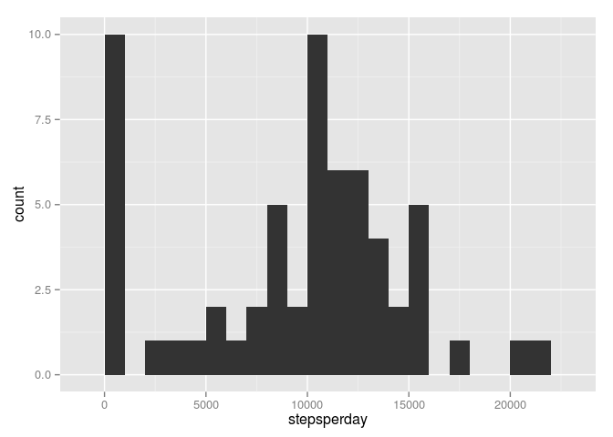

```r
stepsperday <- sapply(split(data$steps,data$date),sum,na.rm = TRUE)
msteps <- mean(stepsperday,na.rm = T)
mdsteps <- median(stepsperday,na.rm = T)
sdsteps <- sd(stepsperday,na.rm = T)
library('ggplot2')
qplot(stepsperday,binwidth=1000,  title="histogram of the total number of steps taken each day")
```

## What is the average daily activity pattern?

```
## geom_smooth: method="auto" and size of largest group is >=1000, so using gam with formula: y ~ s(x, bs = "cs"). Use 'method = x' to change the smoothing method.
```

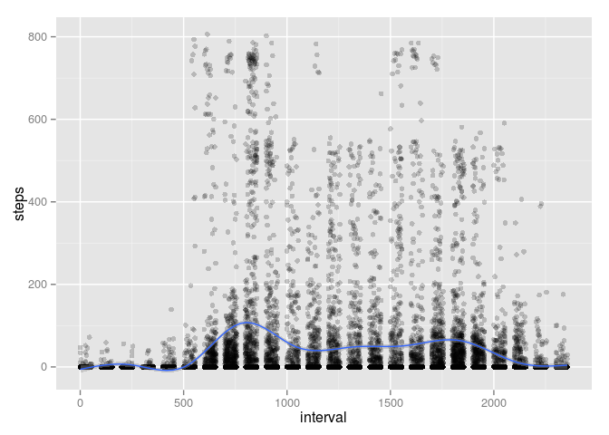

```r
data$day = strftime(data$date,'%A')
#qplot(data = data,x=interval,y=steps,color=day, alpha = I(0.4))+ stat_smooth(na.rm = T)
qplot(data = data,x=interval,y=steps, alpha = I(0.2))+ stat_smooth(na.rm = T)
```

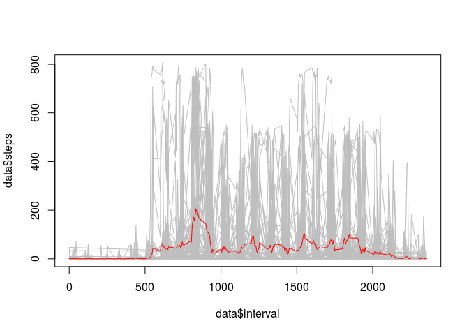

```r
# doing it by hand:
plot(data$steps ~ data$interval,type="l", col="grey")
# now calculating  and plotting mean
stepsperinterval <- sapply(split(DT$steps,DT$interval),mean,na.rm = TRUE)
# creating a timescale
timelist = as.numeric(levels(as.factor(data$interval)))
# overplotting mean
lines(stepsperinterval ~ timelist,type="l",col="red")
```

```r
mostactivetime = data$interval[which.max(stepsperinterval)]
```

The most steps are recorded when the time of day is 835

## Imputing missing values

the total number of missing values in the dataset:

```r
summary(data$step)
```

```
##    Min. 1st Qu.  Median    Mean 3rd Qu.    Max.    NA's
##    0.00    0.00    0.00   37.38   12.00  806.00    2304
```

filling in all of the missing values in the dataset, by imputing with average of that time of day:

```r
imputed_data=data
#find mask of all NA
allnans = is.na(data$steps)
# assigning daytime means to replacemens
replacements = stepsperinterval[as.factor(data$interval)]
imputed_data$steps[allnans]= replacements[allnans]
summary(imputed_data$steps)
```

```
##    Min. 1st Qu.  Median    Mean 3rd Qu.    Max.
##    0.00    0.00    0.00   37.38   27.00  806.00
```

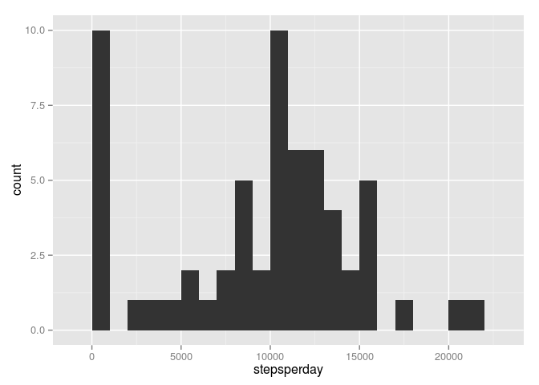

```r
stepsperday_imputed <- sapply(split(imputed_data$steps,imputed_data$date),sum,na.rm = TRUE)
msteps_imputed <- mean(stepsperday_imputed,na.rm = T)
mdsteps_imputed <- median(stepsperday_imputed,na.rm = T)
sdsteps_imputed <- sd(stepsperday_imputed,na.rm = T)
qplot(stepsperday,binwidth=1000)
```

## Are there differences in activity patterns between weekdays and weekends?

```
## geom_smooth: method="auto" and size of largest group is >=1000, so using gam with formula: y ~ s(x, bs = "cs"). Use 'method = x' to change the smoothing method.
## geom_smooth: method="auto" and size of largest group is >=1000, so using gam with formula: y ~ s(x, bs = "cs"). Use 'method = x' to change the smoothing method.
```

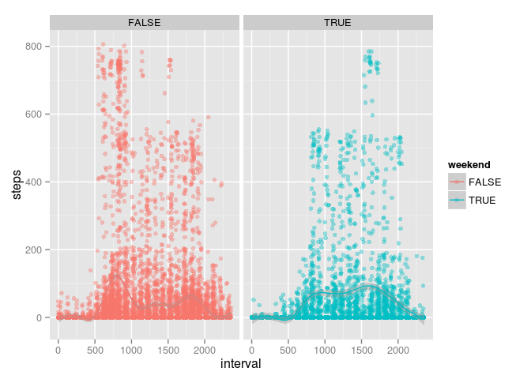

```r
data$weekend = (data$day %in% c("Sunday","Saturday"))
qplot(data = data,x=interval,y=steps,color=weekend,facets=.~ weekend, alpha = I(0.4))+ stat_smooth(na.rm = T)
```

```
## geom_smooth: method="auto" and size of largest group is >=1000, so using gam with formula: y ~ s(x, bs = "cs"). Use 'method = x' to change the smoothing method.
```

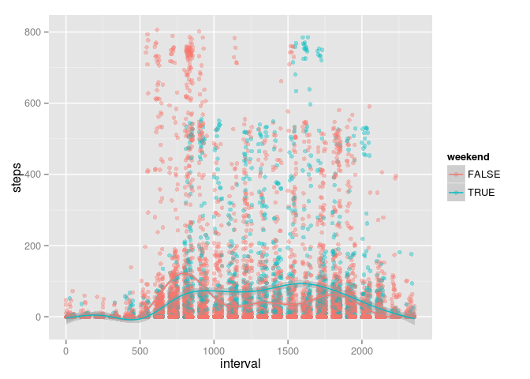

```r
## and overlay
qplot(data = data,x=interval,y=steps,color=weekend,alpha = I(0.4))+ stat_smooth(na.rm = T)
```

There is a clear difference. The morining commute peak is missing at the weekens. Instead more steps are recorded in the afternoon.